# US Name

Estimate kandhelwal_quality as a function of ln_lag_tax_rebate and others variables

# Description

## Variables

### Target

- kandhelwal_quality

### Features

- ln_lag_tax_rebate
- regime

## Complementary information

# Metadata

- Key: 183_VAT_rebate_quality
- Epic: Models
- US:
- Task tag: #data-analysis
- Analytics reports:

# Input Cloud Storage

## Table/file

**Name**

- https://github.com/thomaspernet/VAT_rebate_quality_china/blob/master/01_data_preprocessing/02_transform_tables/04_baseline_vat_quantity_covariates.md

**Github**

- china_vat_quality

# Load tables

Since we load the data as a Pandas DataFrame, we want to pass the `dtypes`. We load the schema from Glue to guess the types

|  | Name | Type | Comment |
| --- | --- | --- | --- |
| 0 | geocode4_corr | string | city name |
| 1 | year | string | year |
| 2 | regime | varchar(12) | eligible or no eligible to vat rebate |
| 3 | hs6 | string | HS6 6 digit |
| 4 | hs4 | string | HS4 4 digit |
| 5 | hs3 | string | HS3 3 digit |
| 6 | hs2 | string | HS2 2 digit |
| 7 | homogeneous | string | Goods label |
| 8 | country_en | string | English country name |
| 9 | iso_alpha | string |  |
| 10 | gni_per_capita | float | GDP per capita is gross domestic product divided by midyear population |
| 11 | gpd_per_capita | float | GNI per capita (formerly GNP per capita) is the gross national income, converted to U.S. dollars using the World Bank Atlas method, divided by the midyear population |
| 12 | income_group | string | One of 'Others', 'Low income', 'Upper middle income','High income: nonOECD', 'Lower middle income', 'High income: OECD' |
| 13 | income_group_ldc_dc | varchar(3) | Income group LDC or not LDC in 2003 |
| 14 | quantity | bigint | Export quantity |
| 15 | value | bigint | Export value |
| 16 | unit_price | decimal(21,5) | product unit price |
| 17 | kandhelwal_quality | float | Kandhelwal quality |
| 18 | price_adjusted_quality | float | price adjusted |
| 19 | lag_vat_m | float | lag vat tax |
| 20 | lag_vat_reb_m | float | lag vat rebate |
| 21 | lag_tax_rebate | float | lag vat rebate to pay |
| 22 | ln_lag_vat_m | double | log lag vat tax |
| 23 | ln_lag_vat_reb_m | double | log lag vat rebate |
| 24 | ln_lag_tax_rebate | double | log lag vat rebate to pay |
| 25 | lag_import_tax | float | lag import tax |
| 26 | ln_lag_import_tax | double | log lag import tax |
| 27 | lag_soe_export_share_ckr | decimal(21,5) | lag export share city industry regime |
| 28 | lag_foreign_export_share_ckr | decimal(21,5) | lag export share city industry regime |
| 29 | high_tech | string | high tech product |
| 30 | energy | string | energy consuming product |
| 31 | skilled | string | skilled sectors |
| 32 | rd_oriented | string | rd_oriented sectors |
| 33 | count_hs6 | bigint | count hs6 |
| 34 | sum_quantity | bigint |  |
| 35 | city_average_hs6 | double |  |
| 36 | city_average_quantity | double |  |
| 37 | size_quantity | varchar(14) |  |
| 38 | size_product | varchar(11) |  |

# compute fixed effect

| Benchmark | Origin | Name | Description | Math_notebook |
| --- | --- | --- | --- | --- |
| Yes | Current | city-product |  | $\alpha_{ck}$ |
| Yes | Current | city-product-regime |  | $\alpha_{ck}^R$ |
| Yes | Current | city-sector-year | Sector is defined as GBT 4 digit | $\alpha_{cst}$ |
| Yes | Current | city-sectorーregime-year | Sector is defined as GBT 4 digit | $\alpha_{cst}^R$ |
| Yes | Current | product-destination |  | $\alpha_{pj}$ |
| Yes | Previous baseline | Product-year | account for all factors that affect product-level export irrespective of the trade regime in a given year | $\alpha_{pt}$ |
| No | Previous baseline | firm-product-eligibility | captures all the factors that affect firms regardless of the time and type of regime. This firm‒product pair eliminates the demand shocks that firms face and that are not correlated with the types of … | $\alpha^{E}_{it}$ |
| No | Previous baseline | HS4-year-eligibility |  | $\alpha^{E}_{st}$ |
| No | Previous baseline | city-year | captures the differences in demand, capital intensity, or labor supply that prevail between cities each year | $\alpha_{ct}$ |
| No | Candidate | destination-year | Captures additional level of control, encompassing all the shocks and developments in the economies to which China exports. | $\alpha_{dt}$ |

Create the following fixed effect for the baseline regression:

**index**

- city: `c`
- product: `k`
- sector: `s`
- year: `t`
- Destination: `j`
- regime: `r`

**FE**

- city-product: `FE_ck`
- City-sector-year: `FE_cst`
- City-product-regime: `FE_ckr`
- City-sector-regime-year: `FE_csrt`
- Product-year: `FE_kt`
- Product-destination: `FE_pj`
- Destination-year: `FE_jt`

## Schema Latex table

To rename a variable, please use the following template:

```
{
    'old':'XX',
    'new':'XX_1'
    }
```

if you need to pass a latex format with `\`, you need to duplicate it for instance, `\text` becomes `\text:

```
{
    'old':'working\_capital\_i',
    'new':'\\text{working capital}_i'
    }
```

Then add it to the key `to_rename`

```
 Hlavac, Marek (2018). stargazer: Well-Formatted Regression and Summary Statistics Tables.
 R package version 5.2.2. https://CRAN.R-project.org/package=stargazer
```

| geocode4_corr | year | regime | hs6 | hs4 | hs3 | hs2 | homogeneous | country_en | iso_alpha | ... | size_product | fe_ck | fe_cst | fe_ckr | fe_csrt | fe_kt | fe_kj | fe_jt | fe_ckj | fe_group_shock |
| --- | --- | --- | --- | --- | --- | --- | --- | --- | --- | --- | --- | --- | --- | --- | --- | --- | --- | --- | --- | --- |
| 3505 | 2004 | ELIGIBLE | 252210 | 2522 | 252 | 25 | HETEREGENEOUS | Jordan | JOR | ... | LARGE_COUNT | 0 | 0 | 0 | 0 | 0 | 0 | 0 | 0 | 0 |
| 3505 | 2004 | ELIGIBLE | 852033 | 8520 | 852 | 85 | HETEREGENEOUS | India | IND | ... | LARGE_COUNT | 1 | 1 | 1 | 1 | 1 | 1 | 1 | 1 | 1 |
| 3505 | 2010 | ELIGIBLE | 680990 | 6809 | 680 | 68 | HETEREGENEOUS | Taiwan | TWN | ... | LARGE_COUNT | 2 | 2 | 2 | 2 | 2 | 2 | 2 | 2 | 2 |
| 3505 | 2008 | ELIGIBLE | 870829 | 8708 | 870 | 87 | HETEREGENEOUS | South Africa | ZAF | ... | LARGE_COUNT | 3 | 3 | 3 | 3 | 3 | 3 | 3 | 3 | 3 |
| 3505 | 2010 | ELIGIBLE | 620113 | 6201 | 620 | 62 | HETEREGENEOUS | Italy | ITA | ... | LARGE_COUNT | 4 | 4 | 4 | 4 | 4 | 4 | 4 | 4 | 4 |
| 3505 | 2010 | ELIGIBLE | 845959 | 8459 | 845 | 84 | HETEREGENEOUS | Mexico | MEX | ... | LARGE_COUNT | 5 | 5 | 5 | 5 | 5 | 5 | 5 | 5 | 5 |

## Table 1: baseline estimate

$$ \begin{aligned} \operatorname{Quality}_{c,k,j, t}^{R} &=\alpha \ln \text{VAT Export tax}_{k, t-1} \times \text { Eligibility }^{R} \\ &+\alpha \ln \text{Import tax} \times \text { Eligibility }^{R} \\ &+X_{c, s, t-1}^{R}+F E_{c,k}^{R}+F E_{c,s,t}^{R}+ F E_{k, t}+\epsilon_{ck,j, t}^{R} \end{aligned} $$

- Column 1: Estimate for eligible regime only
  - FE:
    - city-product: `fe_ck`
    - city-sector-year: `fe_cst`
    - product-destination: `fe_pj`
- Column 2: Estimate for non-eligible regime only
  - FE:
    - city-product: `fe_ck`
    - city-sector-year: `fe_cst`
    - product-destination: `fe_pj`
- Column 3: Full estimate without product-year FE -> Get two coefficients
  - FE:
    - city-product-regime: `fe_ckr`
    - city-sector-regime-year: `fe_csrt`
    - product-destination: `fe_pj`
- Column 4: Baseline estimate -> Focus on the coef of interest only
  - FE:
    - city-product-regime: `fe_ckr`
    - city-sector-regime-year: `fe_csrt`
    - product-year: `fe_kt`
- Column 5: Full estimate without product-year FE -> Get two coefficients & additional covariates
  - FE:
    - city-product-regime: `fe_ckr`
    - city-sector-regime-year: `fe_csrt`
    - product-destination: `fe_pj`
- Column 6: Baseline estimate -> Focus on the coef of interest only & additional covariates
  - FE:
    - city-product-regime: `fe_ckr`
    - city-sector-regime-year: `fe_csrt`
    - product-year: `fe_kt`

Sector is defined as the GBT 4 digits

```
[1] "table 0 done"
[1] "table 1 done"
[1] "table 2 done"
[1] "table 3 done"
[1] "table 4 done"
[1] "table 5 done"
```

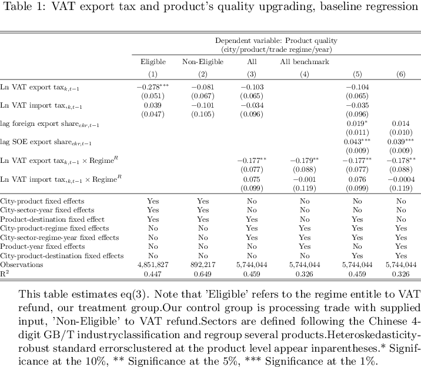

### Test Price adjusted

```
[1] "table 0 done"
[1] "table 1 done"
[1] "table 2 done"
[1] "table 3 done"
[1] "table 4 done"
[1] "table 5 done"
```

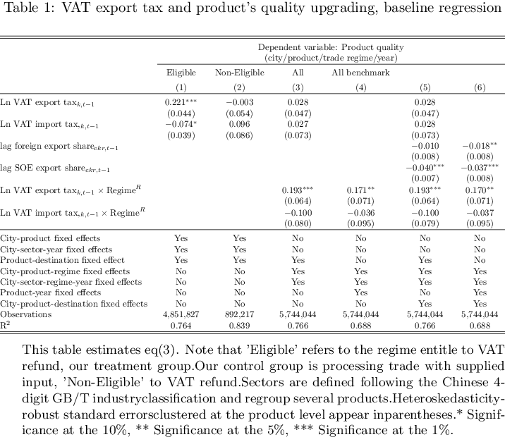

## Table 2: Heterogeneity effect

Sector is defined as the GBT 4 digits

```
[1] "table 0 done"
[1] "table 1 done"
[1] "table 2 done"
[1] "table 3 done"
[1] "table 4 done"
[1] "table 5 done"
[1] "table 6 done"
[1] "table 7 done"
```

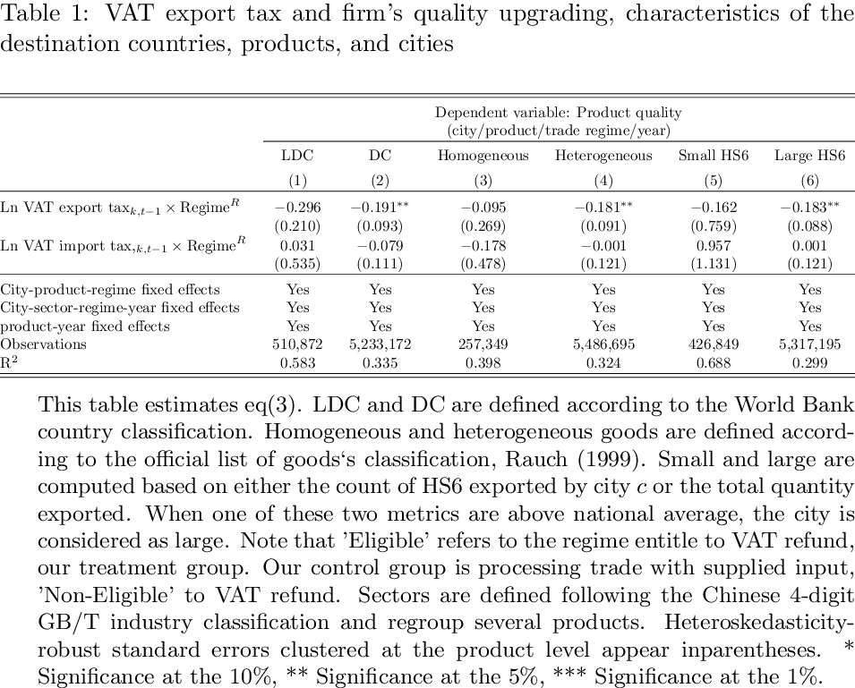

## Table 3: Industry characteristicts

- Column 1 excludes rare earth products with the main fixed effect:
  - city-product-regime: `fe_ckr`
  - city-sector-regime-year: `fe_csrt`
  - product-year: `fe_kt`
- Column 2 excludes energy intensive industries with the main fixed effect:
  - city-product-regime: `fe_ckr`
  - city-sector-regime-year: `fe_csrt`
  - product-year: `fe_kt`
- Column 3 excludes high tech industries with the main fixed effect:
  - city-product-regime: `fe_ckr`
  - city-sector-regime-year: `fe_csrt`
  - product-year: `fe_kt`
- Column 4 excludes RD oriented indusrtries with the main fixed effect:
  - city-product-regime: `fe_ckr`
  - city-sector-regime-year: `fe_csrt`
  - product-year: `fe_kt`
- Column 5 excludes High skilled oriented with the main fixed effect:
  - city-product-regime: `fe_ckr`
  - city-sector-regime-year: `fe_csrt`
  - product-year: `fe_kt`

Sector is defined as the GBT 4 digits

```
[1] "table 0 done"
[1] "table 1 done"
[1] "table 2 done"
[1] "table 3 done"
[1] "table 4 done"
```

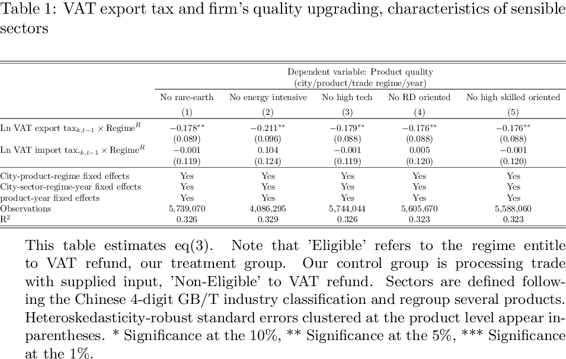

## Table 5: Robustness check

- Column 1 add shocks with the main fixed effect:
  - city-product-regime: fe_ckr
  - city-sector-regime-year: fe_csrt
  - product-year: fe_kt
  - Shocks: hs6 + destination + year = 2003
- Column 2 includes cities presents full years with the main fixed effect:
  - city-product-regime: fe_ckr
  - city-sector-regime-year: fe_csrt
  - product-year: fe_kt
- Column 3 switch eligible to non eligle with the main fixed effect:
  - city-product-regime: fe_ckr
  - city-sector-regime-year: fe_csrt
  - product-year: fe_kt
- Column 4 switch non eligible to eligible with the main fixed effect:
  - city-product-regime: fe_ckr
  - city-sector-regime-year: fe_csrt
  - product-year: fe_kt
- Column 5 keep rebates 17% with the main fixed effect:
  - city-product-regime: fe_ckr
  - city-sector-regime-year: fe_csrt
  - product-year: fe_kt
- Column 6 exclude rebates 0% with the main fixed effect:
  - city-product-regime: fe_ckr
  - city-sector-regime-year: fe_csrt
  - product-year: fe_kt

```
[1] "table 0 done"
[1] "table 1 done"
```

```
[1] "table 2 done"
```

```
[1] "table 3 done"
[1] "table 4 done"
[1] "table 5 done"
```

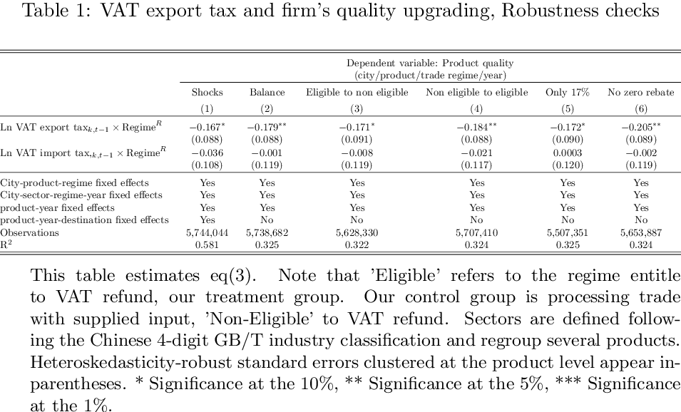

# Generate reports

```
Report Available at this adress:
 /home/ubuntu/VAT_rebate_quality_china/02_data_analysis/01_model_estimation/00_replicate_previous/Reports/00_previous_tables.html
```